# Wins

Rodrigo Motoyama

5/8/2020

# Estatística “Win” - Todos por um, e esse um sai como herói (ou vilão)

## Record

Se você já assistiu alguns jogos da MLB, você provavelmente já se deparou com o “record” de um arremessador. Aqueles dois numerozinhos separados por um “-”, sabe?

[figure not shown]

Na foto, podemos ver o primeiro arremessador brasileiro a chegar na MLB, Andre Rienzo. Na ocasião, Rienzo possuía um “record” de 2–2. “Mas, 2–2 o quê?” Bom, cada número representa uma estatística. O primeiro 2 é o número de vitórias que o Rienzo conseguiu na temporada até aquele momento, e o segundo 2 é o número de derrotas. Fácil, né? Você pode pensar — “Quanto mais o arremessador ganhar, melhor ele é, e quanto mais ele perder, pior ele é.” Quem dera se as coisas fossem simples assim.

## Quanto mais vitórias melhor?

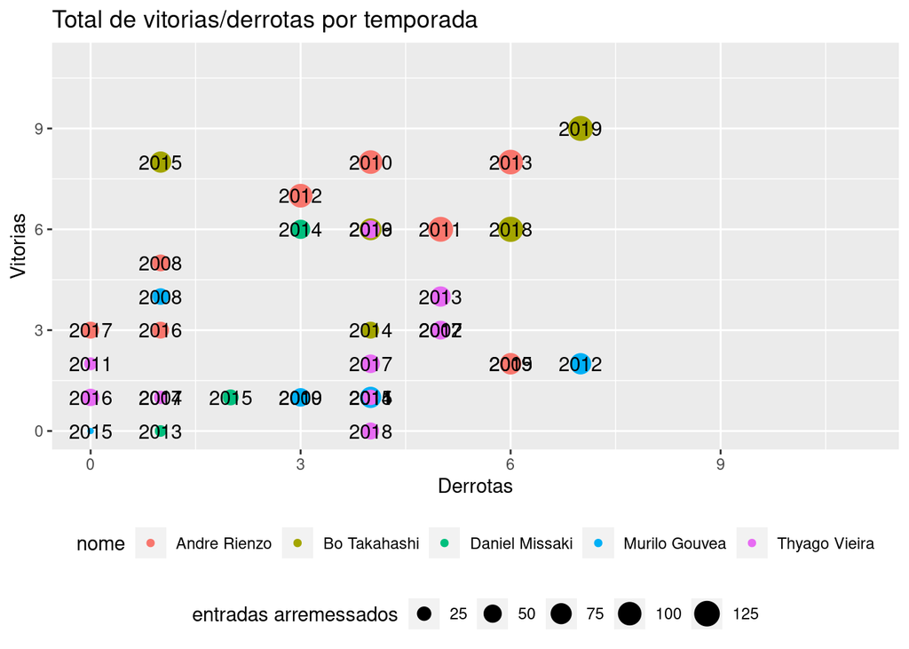

## Vitórias e derrotas

Um arremessador recebe a estatística de vitória (W) quando seu time assume a liderança de vez, com duas exceções. A primeira é que se o arremessador for o abridor (SP/Starting Pitcher), ele precisa arremessar pelo menos metade do jogo, ou seja, 5 entradas na MLB, para se qualificar para a vitória. Além disso, se ele for substituído por um relevo (Relief Pitcher) após arremessar 5+ entradas, seu time precisa se manter na liderança até o fim do jogo, caso contrário, ele perde o direito da vitória.

Existe tambem um caso raro onde um relevo pode ser considerado ineficaz, fazendo com que o anotador não o considere adequado para receber a vitória. Por exemplo, um relevo entra no jogo com uma liderança de 1 corrida e leve 3 pontos. Mas no entrada seguinte, seu time recupere a liderança e esse relevo é substituido. Nesse caso, o anotador pode designar a vitória para o próximo arremessador, porque esse foi considerado ineficaz.

Já uma derrota, é dada para o arremessador responsável pela corrida de virada do time adversário que nunca mais perde essa liderança. Simples assim.

Vamos ver alguns exemplos para tentar entender o que essa estatística de fato mede.

1. Em 2016 no WBC Qualifier (classificatórias para a “copa do mundo” de beisebol), Bo Takahashi abriu o jogo contra Israel. Ele arremessou 4 entradas e cedeu a única corrida do jogo na derrota por 1x0 do Brasil contra Israel. Takahashi cedeu apenas 2 rebatidas validas (H/hits), 1 base por bolas (BB/walk), e conseguiu 5 eliminações por strike (SO/strike out). Mesmo assim, ele saiu com a derrota porque cedeu a corrida da derrota.
2. Ainda em 2016 no WBC Qualifier, Rienzo abriu o jogo contra a Grã-Bretanha arremessando 5 entradas, cedendo 3 rebatidas validas, 3 corridas, mas somente uma merecida (Earned run), 0 bases por bola, e 8 eliminações por strike, quase 2 SO por entrada. Porém, o Brasil não conseguiu empatar nem tomar a liderança em nenhum momento do jogo, fazendo com que Rienzo recebesse a derrota, apesar de ter arremessado 5 entradas muito bem.
3. Nesse mesmo jogo contra a Grã-Bretanha, o arremessador britânico que abriu o jogo arremessou apenas 4 entradas, tornando ele não qualificado a receber a vitória. Por isso que o arremessador seguinte recebe a vitória em seu lugar.
4. Em 2013 no WBC, Brasil enfrentou a China e estava vencendo por 2 a 0 até a parte baixa da oitava entrada, quando ocorreu a virada da China. Nessa entrada, Murilo Gouvea começa arremessando e consegue fazer apena uma eliminação antes de ceder uma rebatida simples, duas bases por bola e ser substituído. Nessa entrada, o Brasil cedeu 5 corridas para a China. Como as 3 primeiras corridas eram de responsabilidade do Murilo Gouvea, ele saiu do jogo como o arremessador perdedor (LP/Losing Pitcher), mesmo não sendo ele que cedeu as rebatidas para aquelas corridas.

## Valor de uma vitória/derrota

Bom, entendemos como vitórias e derrotas são designadas, mas qual o valor delas? O que elas de fato medem? Na minha opinião, nada. Não conseguimos extrair valor de um arremessador somente olhando o record. Porque não basta que o arremessador arremesse bem, ele precisa incentivar o seu time a marcar pontos, caso contrário, ele sairá com a derrota. É a responsabilidade do jogo inteiro em cima de uma pessoa, sendo que temos outras 8 ou 9 em campo.

Eu entendo o apelo desse tipo de estatística na era “dead ball”, onde os rebatedores não se saiam tão bem (poucos chegavam a 10+ home runs), e um abridor arremessava quase todos os jogos inteiros por conta disso. Mas para o beisebol atual, esse tipo de medição não faz sentido. Se um jogador recebe a vitória, não quer dizer que desempenho dele foi bom ou ruim, você não consegue inferir nada sobre a atuação do arremessador pelo record dele.

Uma vitória ou derrota possui valor apenas para o time como um todo. Temos muitas estatísticas que nos ajudam a entender o desempenho de arremessadores, mas W e L não são elas. Elas apenas mascaram aparições ruins que recebem W porque o time marcou mais corridas, e aparições excelentes (Jacob deGrom) que sofem uma derrota por falta de apoio do time.

## Considerações finais

Espero que vocês tenham gostado do texto e das análises. Pretendo usar dados de brasileiros na minor/major em alguns outros posts, mas esse não será o foco. Tentarei intercalar os posts entre estatísticas avançadas (wOBA, SwStr%, wRC+ e etc.), também conhecidas como saberstats, e estatísticas básicas (ERA, BA, OBP, SLG e etc.).

Se vocês gostaram, deixem alguns aplausos para que eu entenda que tipo de post mais agrada vocês e comentem o que acharam que faltou ou que não ficou claro, por favor.

Se possível fiquem em casa e lavem as mãos!

## Referências

- [Wins](http://m.mlb.com/glossary/standard-stats/win)
- [Loss](http://m.mlb.com/glossary/standard-stats/loss)
- [Box Score Brasil x Israel](https://www.mlb.com/gameday/brazil-vs-israel/2016/09/23/467859#game_tab=box,game=467859,game_state=final)
- [Box Score Brasil x Grã-Bretanha](https://www.mlb.com/gameday/brazil-vs-great-britain/2016/09/24/467861#game_tab=box,game=467861,game_state=final)
- [Box Score Brasil x China](http://mlb.mlb.com/wbc/2013/gameday/index.jsp?gid=2013_03_05_braint_chnint_1&mode=box)